# Diamond Price Estimations

Ramazan Eraslan

9/10/2020

## Introduction

This report aims to analyze the certain aspects of the `diamonds` dateset in ggplot2 package and make price estimation for diamonds via using Classification and Regression Tree (CART) method.

## Loading Required Libraries

```r
library(tidyverse)
library(rpart)
library(rpart.plot)
library(Metrics)
```

## Exploratory Data Analysis

```r
summary(diamonds)
```

```
##      carat               cut        color        clarity          depth
##  Min.   :0.2000   Fair     : 1610   D: 6775   SI1    :13065   Min.   :43.00
##  1st Qu.:0.4000   Good     : 4906   E: 9797   VS2    :12258   1st Qu.:61.00
##  Median :0.7000   Very Good:12082   F: 9542   SI2    : 9194   Median :61.80
##  Mean   :0.7979   Premium  :13791   G:11292   VS1    : 8171   Mean   :61.75
##  3rd Qu.:1.0400   Ideal    :21551   H: 8304   VVS2   : 5066   3rd Qu.:62.50
##  Max.   :5.0100                     I: 5422   VVS1   : 3655   Max.   :79.00
##                                     J: 2808   (Other): 2531
##      table           price             x                y
##  Min.   :43.00   Min.   :  326   Min.   : 0.000   Min.   : 0.000
##  1st Qu.:56.00   1st Qu.:  950   1st Qu.: 4.710   1st Qu.: 4.720
##  Median :57.00   Median : 2401   Median : 5.700   Median : 5.710
##  Mean   :57.46   Mean   : 3933   Mean   : 5.731   Mean   : 5.735
##  3rd Qu.:59.00   3rd Qu.: 5324   3rd Qu.: 6.540   3rd Qu.: 6.540
##  Max.   :95.00   Max.   :18823   Max.   :10.740   Max.   :58.900
##
##        z
##  Min.   : 0.000
##  1st Qu.: 2.910
##  Median : 3.530
##  Mean   : 3.539
##  3rd Qu.: 4.040
##  Max.   :31.800
##
```

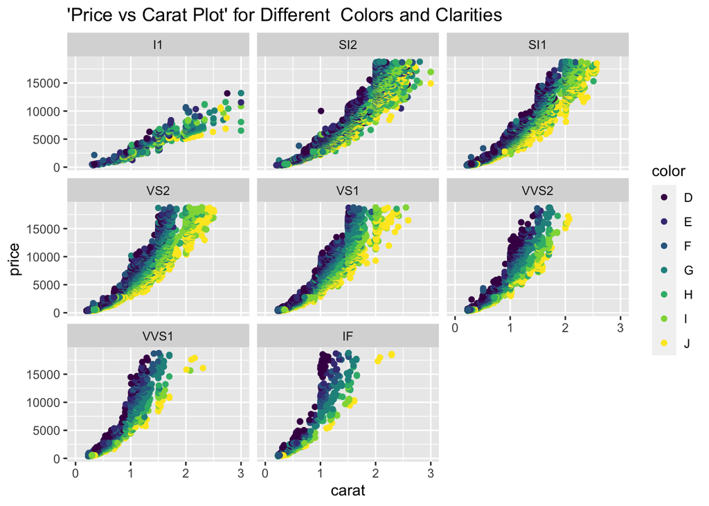

```r
ggplot(diamonds,aes(x=carat,y=price,color=color))+geom_point()+xlim(c(0,3))+facet_wrap(clarity~.)+ggtitle("'Price vs Carat Plot' for Different  Colors and Clarities")
```

This plot shows that price and carat of a diamond are directly proportional. Diamonds with the color denoted by D, have relatively low carat.On the other hand, diamonds with the color denoted by J,generally have high carat. Plots also show that, price of a diamond with color D is higher than the diamonds with other colors, when their carats are the same.

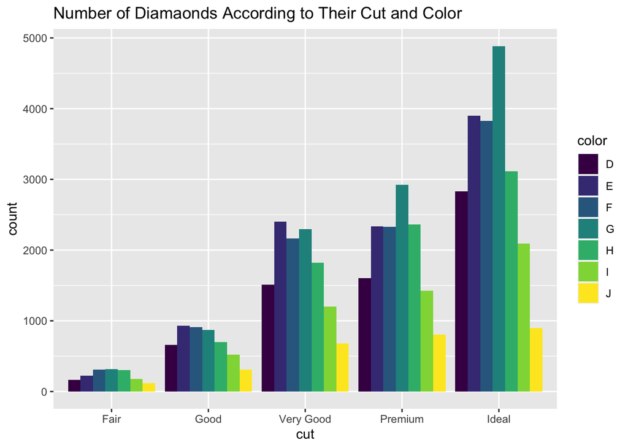

```r
ggplot(diamonds,aes(x=cut,fill=color))+geom_bar(position = "dodge")+ggtitle("Number of Diamaonds According to Their Cut and Color")
```

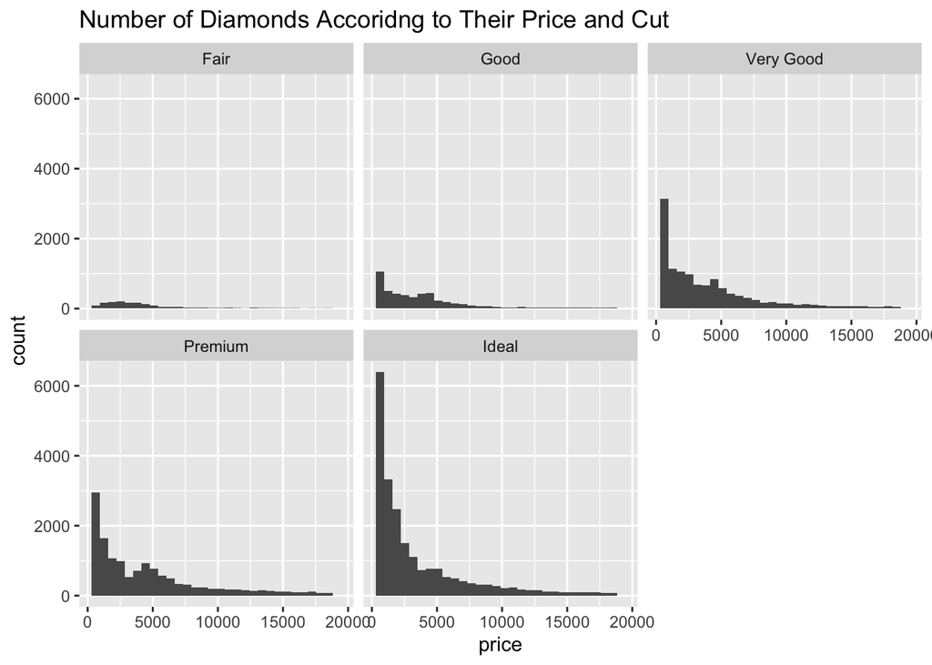

```r
ggplot(diamonds,aes(x=price))+geom_histogram()+facet_wrap(cut~.)+ggtitle("Number of Diamonds Accoridng to Their Price and Cut")
```

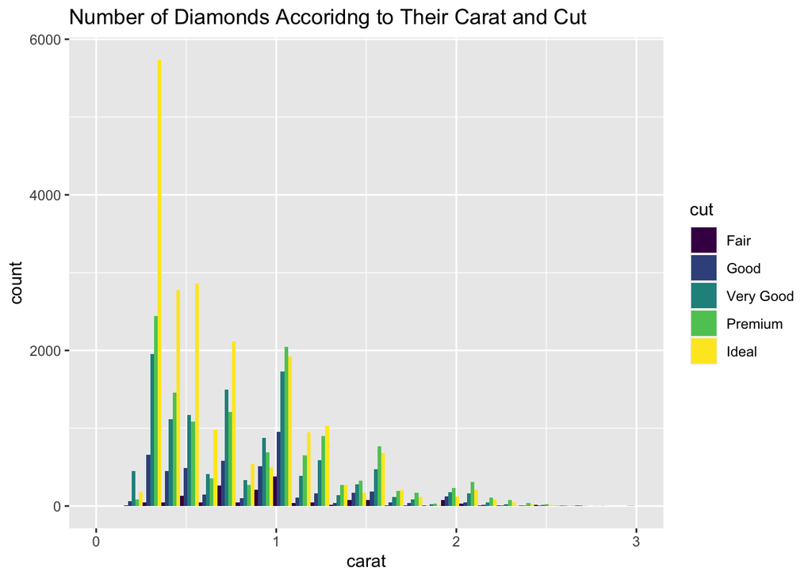

```r
ggplot(diamonds,aes(x=carat,fill=cut))+geom_histogram(position = "dodge")+xlim(c(0,3))+ggtitle("Number of Diamonds Accoridng to Their Carat and Cut")
```

## Price Estimation with CART

### Splitting data into train and test datasets

```r
set.seed(503)

diamonds_test <- diamonds %>% mutate(diamond_id = row_number()) %>%
    group_by(cut, color, clarity) %>% sample_frac(0.2) %>% ungroup()

diamonds_train <- anti_join(diamonds %>% mutate(diamond_id = row_number()),
    diamonds_test, by = "diamond_id")
```

```r
diamonds_train
```

```
## # A tibble: 43,143 x 11
##    carat cut       color clarity depth table price     x     y     z diamond_id
##    <dbl> <ord>     <ord> <ord>   <dbl> <dbl> <int> <dbl> <dbl> <dbl>      <int>
##  1 0.21  Premium   E     SI1      59.8    61   326  3.89  3.84  2.31          2
##  2 0.23  Good      E     VS1      56.9    65   327  4.05  4.07  2.31          3
##  3 0.290 Premium   I     VS2      62.4    58   334  4.2   4.23  2.63          4
##  4 0.31  Good      J     SI2      63.3    58   335  4.34  4.35  2.75          5
##  5 0.24  Very Good I     VVS1     62.3    57   336  3.95  3.98  2.47          7
##  6 0.26  Very Good H     SI1      61.9    55   337  4.07  4.11  2.53          8
##  7 0.22  Fair      E     VS2      65.1    61   337  3.87  3.78  2.49          9
##  8 0.23  Very Good H     VS1      59.4    61   338  4     4.05  2.39         10
##  9 0.3   Good      J     SI1      64      55   339  4.25  4.28  2.73         11
## 10 0.23  Ideal     J     VS1      62.8    56   340  3.93  3.9   2.46         12
## # … with 43,133 more rows
```

```r
diamonds_test
```

```
## # A tibble: 10,797 x 11
##    carat cut   color clarity depth table price     x     y     z diamond_id
##    <dbl> <ord> <ord> <ord>   <dbl> <dbl> <int> <dbl> <dbl> <dbl>      <int>
##  1 1.7   Fair  D     I1       64.7    56  5617  7.46  7.37  4.8       13776
##  2 0.580 Fair  D     SI2      65.1    58  1156  5.25  5.22  3.41      40690
##  3 1     Fair  D     SI2      65.6    66  3767  6.1   6.01  3.97       5152
##  4 1.05  Fair  D     SI2      65.4    59  3816  6.3   6.24  4.1        5359
##  5 0.7   Fair  D     SI2      64.5    60  2167  5.53  5.47  3.55      49828
##  6 0.9   Fair  D     SI2      64.6    59  3847  6.04  6.01  3.89       5510
##  7 1.01  Fair  D     SI2      64.6    56  3003  6.31  6.24  4.05       1555
##  8 1.1   Fair  D     SI2      64.6    54  4725  6.56  6.49  4.22      10151
##  9 0.62  Fair  D     SI2      64.6    57  1410  5.39  5.33  3.46      43397
## 10 1.5   Fair  D     SI2      68.8    57  7469  6.9   6.86  4.73      18359
## # … with 10,787 more rows
```

### Preperation of the data and creating the model

`diamond_id` column was omitted from both `diamonds_train` and `diamonds_test` datasets in order to create model formula easily. Model was created by `rpart()` function. In the model, `price` is the dependent variable and all other variables are independent variables. Method argument of the `rpart()` function is “anova” because the price variable is numeric rather than class.

```r
diamond_train<-diamonds_train%>%
  select(-diamond_id)
diamond_test<-diamonds_test%>%
  select(-diamond_id)
  model<-rpart(formula = price~.,data =diamond_train, method = "anova" )
```

### Decision Tree

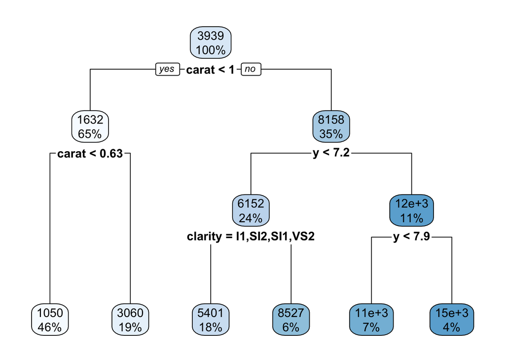

```r
rpart.plot(model)
```

### Evaluating the model

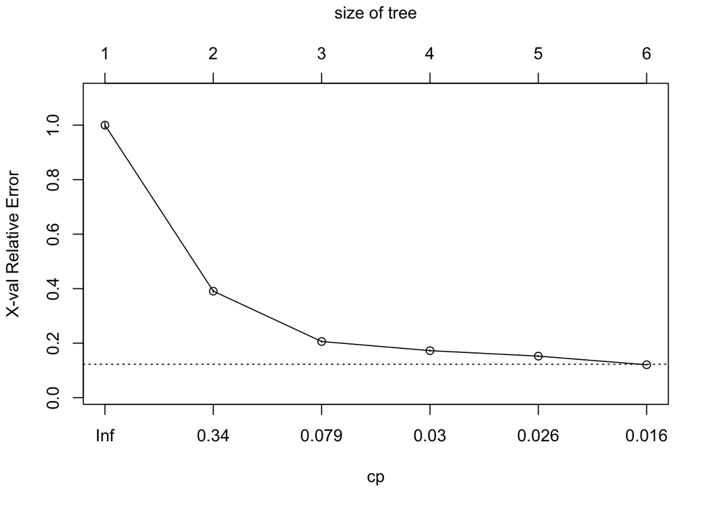

```r
plotcp(model)
```

```r
print(model$cptable)
```

```
##           CP nsplit rel error    xerror        xstd
## 1 0.60913716      0 1.0000000 1.0000357 0.009817373
## 2 0.18517972      1 0.3908628 0.3909391 0.004372856
## 3 0.03361554      2 0.2056831 0.2061950 0.002303084
## 4 0.02661853      3 0.1720676 0.1726668 0.002299963
## 5 0.02583190      4 0.1454491 0.1525199 0.002060203
## 6 0.01000000      5 0.1196172 0.1209142 0.001742561
```

### Predictions

```r
predictions<-predict(model,diamonds_test,type = "vector")

predict_vs_actual<- diamond_test %>%
  select(price)%>%
  mutate(prediction=predictions, abs_difference=abs(price-prediction),abs_percentage=abs(price-prediction)/price)
predict_vs_actual
```

```
## # A tibble: 10,797 x 4
##    price prediction abs_difference abs_percentage
##    <int>      <dbl>          <dbl>          <dbl>
##  1  5617     10941.          5324.         0.948
##  2  1156      1050.           106.         0.0914
##  3  3767      5401.          1634.         0.434
##  4  3816      5401.          1585.         0.415
##  5  2167      3060.           893.         0.412
##  6  3847      3060.           787.         0.205
##  7  3003      5401.          2398.         0.799
##  8  4725      5401.           676.         0.143
##  9  1410      1050.           360.         0.255
## 10  7469      5401.          2068.         0.277
## # … with 10,787 more rows
```

### Errors

Root Mean Squared Error (RMSE) and Mean Absolute (MAE) Error terms for predictions:

```r
errors<-c(RMSE=Metrics::rmse(actual = diamond_test$price,predicted = predictions),MAE=
Metrics::mae(actual =diamond_test$price,predicted = predictions ))
errors
```

```
##      RMSE       MAE
## 1379.1496  890.0513
```

## References

1. https://www.tidyverse.org/